# TumourSurvival

Anika Watson

12/10/2020

## R Markdown

This is an R Markdown document so you can see the code and the outputs even if you don’t have R.

First, let’s get all the boring stuff out of the way. I’ve left it in here in case you want to learn to code in R, but if you don’t care feel free to skip ahead.

```r
#load packages
library(matlab)
#create input+output folder
wd <- getwd()

#check if input folder already exists otherwise create one
#####ATTENTION:data to work with should be stored in this folder before running the code!!
folders <- "data_input"
if (file.exists(folders) == FALSE) {
  dir.create(file.path(wd, folders), showWarnings = FALSE)
} else print("Input Folder Already exists")
```

```
## [1] "Input Folder Already exists"
```

```r
#output folder check
figures <- "figures"
if (file.exists(figures) == FALSE) {
  dir.create(file.path(wd, figures), showWarnings = FALSE)
} else print("Output Folder Already exists")
```

```
## [1] "Output Folder Already exists"
```

```r
#map folders to R structure
outputlocation <- paste(wd, "/figures/" , sep = "")
inputlocation <- paste(wd, "/data_input/" , sep = "")
data.files <- list.files(inputlocation)
```

Now let’s load the data Chris got from Rick’s code,

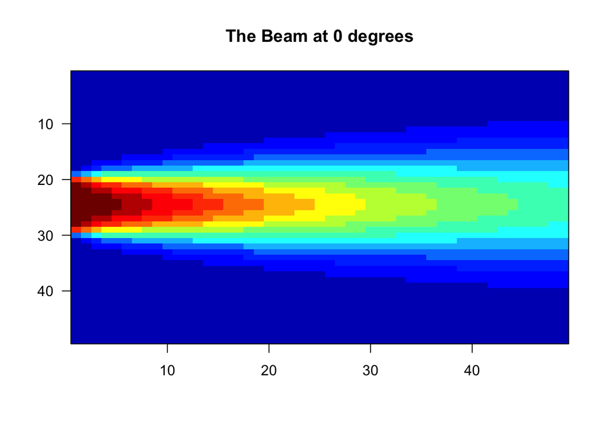

```r
#inital load of data
dose <- read.csv(paste(inputlocation, data.files[1], sep=""), stringsAsFactors = FALSE )

#And of course let's see what the data looks like
imagesc(as.matrix(dose), xlab="", ylab="", col=jet.colors(16), main = "The Beam at 0 degrees")
```

So far so good, we have successfully loaded the data and are ready to boogie!

## Rotating the Beam

First up, let’s figure out how to rotate the beam an angle $\theta_1$. We are going to achieve this by populating a new data frame with the strength of the angled beam at each point.

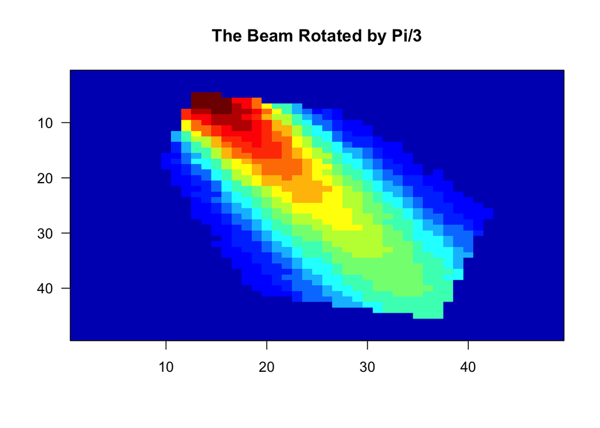

```r
#First let's tell the computer how many iterations we need to fill the grid
iterationsx = dim(dose)[1]
iterationsy = dim(dose)[2]
#now let's set the angle that we want to rotate the beam
theta1 = pi/3
#and define the rotation matrix that will rotate a vector by that amount
rotation1 = c(cos(theta1), sin(theta1), -sin(theta1), cos(theta1))
A1 = matrix(rotation1, nrow = 2, ncol = 2)
#Now let's make an empty grid (its technically a matrix) to populate with the dosage values
output1 <- matrix(ncol=iterationsy, nrow=iterationsx)
#And now we can populate that grid with the new dosage values from the rotated beam using a for loop
for(i in 1:iterationsx){
  for(j in 1:iterationsy){
    #now we turn the cell into a vector
    vec = matrix(c((i-25),(j-25)), nrow = 2, ncol = 1)
    #and apply the rotation matrix to our vector
    rot = A1 %*% vec
    #we can only include this vector in the datafram if it doesn't get rotated out of the square so...
    if(norm(rot)<24){
    output1[i,j] <- dose[(round(rot[1])+25), (round(rot[2])+25)]
    } else {
      output1[i,j] <- 0}
    }
}
#And let's take a peek to ensure we rotated the beam and didn't cause complete chaos
imagesc(output1, xlab="", ylab="", col=jet.colors(16), main = "The Beam Rotated by Pi/3")
```

Yay the beam has rotated! Notice however that part of the beam got cut off when we rotated the square grid. This will be okay as long as the tumours we consider reside within a distance of 24.5 square widths of the centre.

If we want to consider multiple beams penetrating from different angles, say $\theta_2$ and $\theta_3$, then we can simply repeat this process.

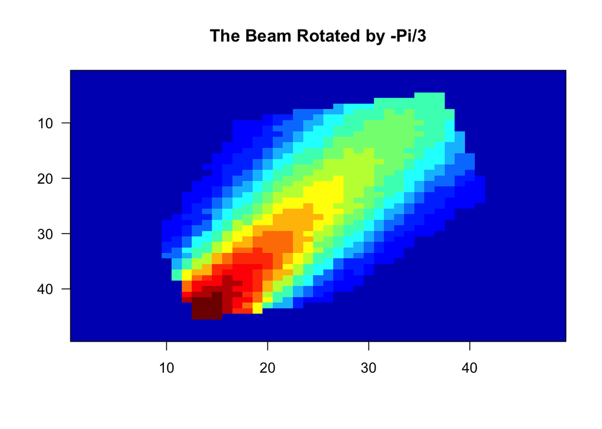

```r
#set the angle
theta2 = -pi/3
#define the rotation matrix
rotation2 = c(cos(theta2), sin(theta2), -sin(theta2), cos(theta2))
A2 = matrix(rotation2, nrow = 2, ncol = 2)
#make an empty grid
output2 <- matrix(ncol=iterationsy, nrow=iterationsx)
#populate that grid with the new dosage values
for(i in 1:iterationsx){
  for(j in 1:iterationsy){
    vec = matrix(c((i-25),(j-25)), nrow = 2, ncol = 1)
    rot = A2 %*% vec
    if(norm(rot)<24){
      output2[i,j] <- dose[(round(rot[1])+25), (round(rot[2])+25)]
    } else {
      output2[i,j] <- 0}
  }
}

#ensure we rotated the beam and didn't cause complete chaos
imagesc(output2, xlab="", ylab="", col=jet.colors(16), main = "The Beam Rotated by -Pi/3")
```

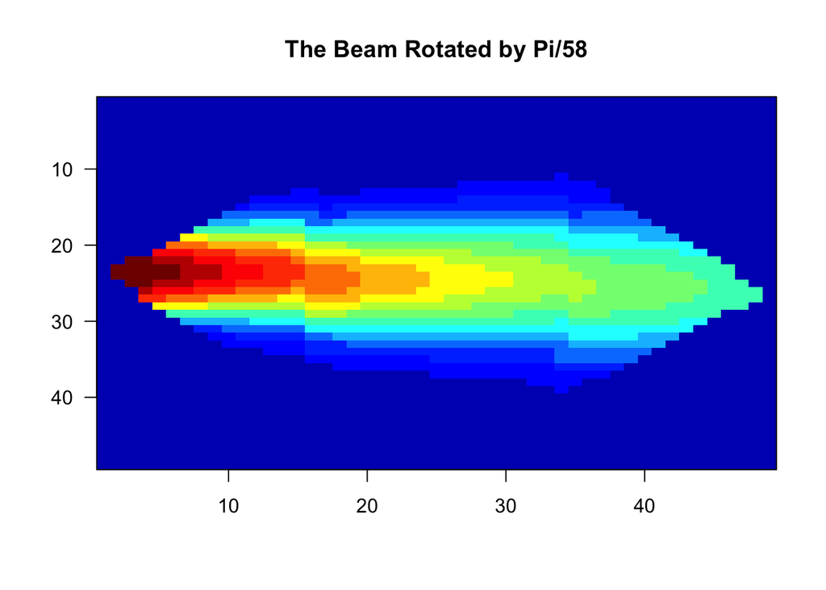

```r
#set the angle
theta3 = pi/58
#define the rotation matrix
rotation3 = c(cos(theta3), sin(theta3), -sin(theta3), cos(theta3))
A3 = matrix(rotation3, nrow = 2, ncol = 2)
#make an empty grid
output3 <- matrix(ncol=iterationsy, nrow=iterationsx)
#populate that grid
for(i in 1:iterationsx){
  for(j in 1:iterationsy){
    vec = matrix(c((i-25),(j-25)), nrow = 2, ncol = 1)
    rot = A3 %*% vec
    if(norm(rot)<24){
      output3[i,j] <- dose[(round(rot[1])+25), (round(rot[2])+25)]
    } else {
      output3[i,j] <- 0}
  }
}

#ensure we rotated the beam and didn't cause complete chaos
imagesc(output3, xlab="", ylab="", col=jet.colors(16), main = "The Beam Rotated by Pi/58")
```

## Finding the Total Dosage at Each Point

Now that we have calculated how much radiation each beam deposits at each point, we can take the sum over the beams to calculate the total amount of radiation received at each point.

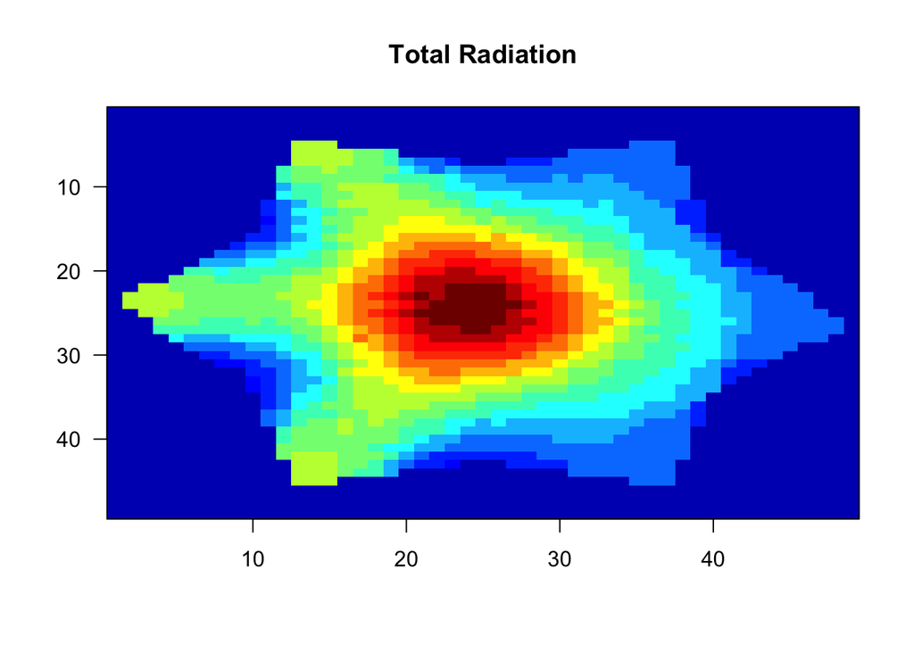

```r
#Let's make a data frame of the total dose received at each  point
TotalDose <- matrix(ncol=iterationsy, nrow=iterationsx)

#And now we can populate that grid with the sum of the doses we found above
for(i in 1:iterationsx){
  for(j in 1:iterationsy){
    TotalDose[i,j] <- output1[i,j]+output2[i,j]+output3[i,j]
        }
}
#make sure that the matrix was populated
imagesc(TotalDose, xlab="", ylab="", col=jet.colors(16), main = "Total Radiation")
```

This image shows the total dosage deposited within the region. Recall that the heat mao may not be accurate at points outside a circle of radius 24.5 since we canculated it by rotating a square of width 49

## Time to Introduce a Tumour

THis is all fine and well but we’re supposed to be calculating the amount a tumour survives and so far there’s no tumour! Let’s fix that and load a tumour I generated in Excel.

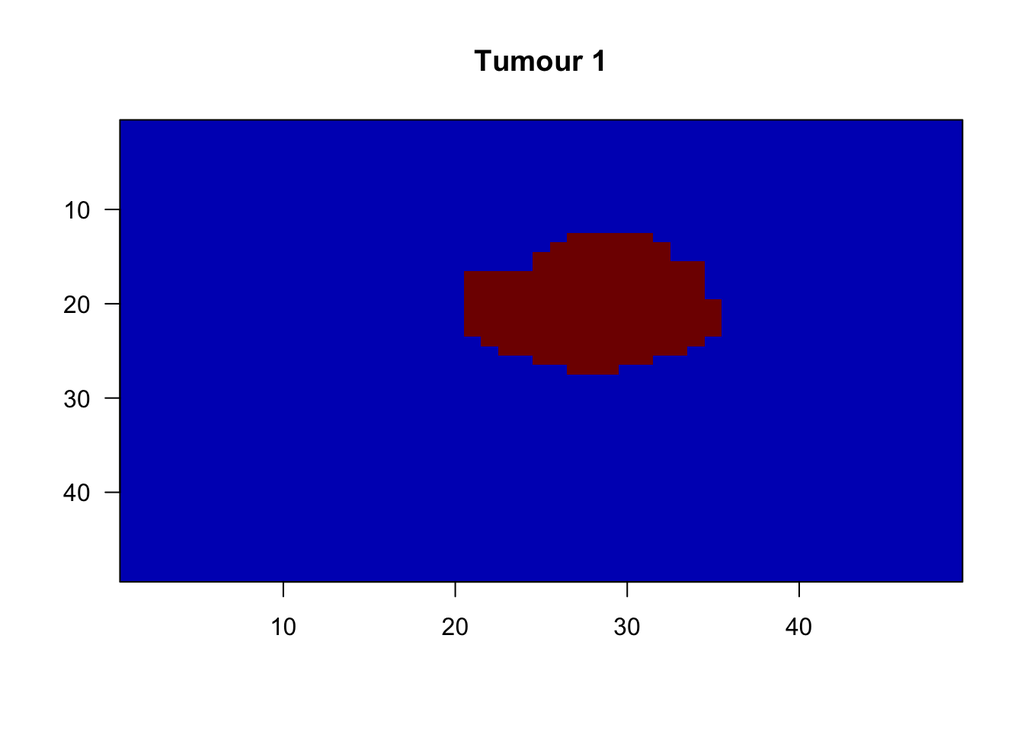

```r
#we need a tumour, so let's load some tumour data
Tumour1 <- read.csv(paste(inputlocation, data.files[3], sep=""), stringsAsFactors = FALSE )
#Let's see what the data looks like
imagesc(as.matrix(Tumour1), xlab="", ylab="", col=jet.colors(16), main = "Tumour 1")
```

Looks like we successfully loaded the tumour, time to calculate the dose received at each point.

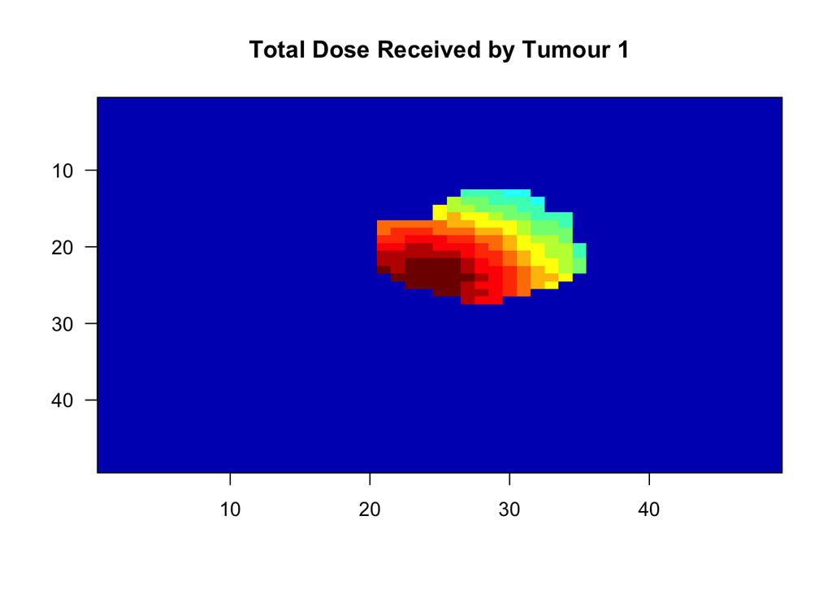

```r
#Let's make a data frame of the total dose received at each point in the tumour
#again, we start with a grid
TumourDose1 <- matrix(ncol=iterationsy, nrow=iterationsx)

#And we populate that grid
for(i in 1:iterationsx){
  for(j in 1:iterationsy){
    TumourDose1[i,j] <- TotalDose[i,j]*Tumour1[i,j]
  }
}

#take a peek
imagesc(TumourDose1, xlab="", ylab="", col=jet.colors(16), main = "Total Dose Received by Tumour 1")
```

Here we see how much radiation each point in the tumour would hypothetically receive given this beam configuration. But we don’t want to know how much radiation the tumour gets, we want to know how much of it survives.

## Calculating the Survival Rate at Each Point in the Tumour

This is where the Linear Quadratic model comes in. This model has parameters $\alpha$ and $\beta$ so let’s define those.

```r
#First we set alpha and beta as defined in the paper
a=1
b=1
```

Obviously I picked the easiest number I could thing of here but we can change that later after researching what values will be appropriate. Having settled on these parameters, let’s calculate the $S(p)$ value for each point in the tumour.

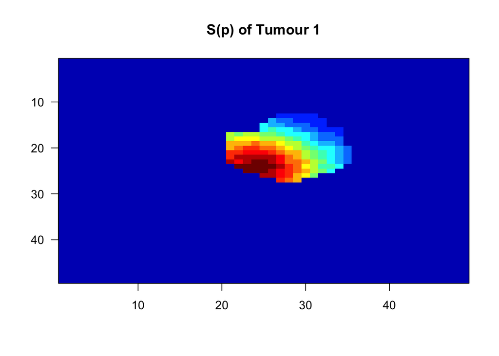

```r
#Next we need a data frame of the cell survival
CellSurvival1 <- matrix(ncol=iterationsy, nrow=iterationsx)

for(i in 1:iterationsx){
  for(j in 1:iterationsy){
    CellSurvival1[i,j] <- a*(TumourDose1[i,j])+b*(TumourDose1[i,j])^2
  }
}
#and let's just see how this looks
imagesc(CellSurvival1, xlab="", ylab="", col=jet.colors(16), main = "S(p) of Tumour 1")
```

As expected this heat map looks quite similar to the heat map of the radiation of the tumour, but this one seems to fade more quickly to the dark blue. Thic is consistent with a linear-quadratic function and is reassuring!

## Quantifying How Much of the Tumour Survives

Ok we know the survival rate $S(p)$ for each cell, but how do we determine how much of the tumour dies? It’s a bit tricky to know with a heat map, so let’s make a histogram to see how many points in the tumour have any given $S(p)$ value.

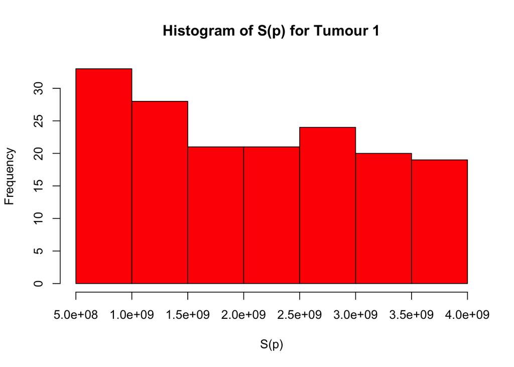

```r
#First we need to get rid of all the zeros everywhere outside the tumour
#because that will throw the histogram off
HowZapped1 <- matrix(ncol=iterationsy, nrow=iterationsx)
for(i in 1:iterationsx){
  for(j in 1:iterationsy){
    if(Tumour1[i,j] == 1){
      HowZapped1[i,j] <- CellSurvival1[i,j]
    } else {
      HowZapped1[i,j] <- NA}
  }
}
HowZapped1 <- data.frame(HowZapped1)

#now we can safely create a histogram
hist(unlist(HowZapped1), main = "Histogram of S(p) for Tumour 1", xlab = "S(p)", col = "red")
```

The histogram is fairly flat so it looks like the dose was relatively consistent acrossthe tumour. But no one wants to be shown a histogram like this when they ask “how much of the tumour is likely to survive?” So let’s pick a cutoff value for $S(p)$ at which point the tumour cells will be presumed dead.

```r
cutoff = 1000000000
```

This was a pretty arbitrary number. I picked it by looking at the histogram and choosing the nearest order of magnitude. We can come back to this after researching what number is realistic.

Now that we have chosen a cutoff value, we can count the number of gridcells in the tumour that have received adequate radiation to have died.

```r
#to count the dead cells we can use another for loop that adds 1 to the deadcell tally
#each time a cell has a cell survival score greater than the cutoff value
deadcells1 = 0
for(i in 1:iterationsx){
  for(j in 1:iterationsy){
    if(CellSurvival1[i,j]>cutoff){
      deadcells1 <- deadcells1+1
    }
    }
}
#let's see how many we got!
deadcells1
```

```
## [1] 133
```

Woohoo we killed 133 tumour cells… well… not really. This number does not actually have any physically significant value on its own because it depends on the dimension we chose for our original data frame. To make sense of this umber we need to compare it to the size of the tumour. So let’s calculate that!

```r
#we can quantify the size of the original tumour by counting its cells as we did the dead ones
totcells1 = 0
for(i in 1:iterationsx){
  for(j in 1:iterationsy){
    if(Tumour1[i,j] == 1){
      totcells1 <- totcells1+1
    }
  }
}
#check the number
totcells1
```

```
## [1] 166
```

Now we have enough information to calculate the percentage of the tumour we predict will survive the radiation treatment modeled.

```r
#now we can calculate the percentage of the tumour that survives
survived1 = 100*(totcells1-deadcells1)/totcells1

#check the number
survived1
```

```
## [1] 19.87952
```

According to these calculations about 20% of the tumour is likely to survive this treatment. Considering that the beams were not optimized for this tumour I’d say this isn’t bad, but there are a lot of values to research before this number has any meaning. Perhaps we can research actual rediotherapy kill rates to compare with this figure once we have found more realistic values for $\alpha$, $\beta$, and the cutoff.

Of course, if we wanted to try this on a different tumour we could easily replicate this code for another one.

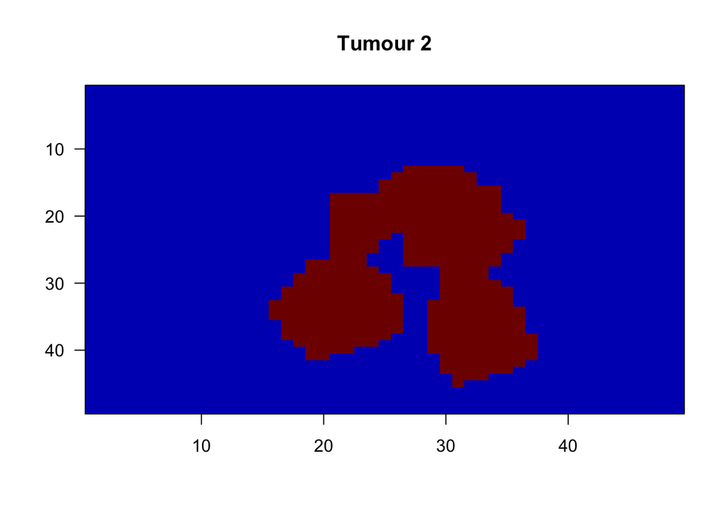

```r
#To do so we need a new tumour
Tumour2 <- read.csv(paste(inputlocation, data.files[4], sep=""), stringsAsFactors = FALSE )
#Let's see what the data looks like
imagesc(as.matrix(Tumour2), xlab="", ylab="", col=jet.colors(16), main = "Tumour 2")
```

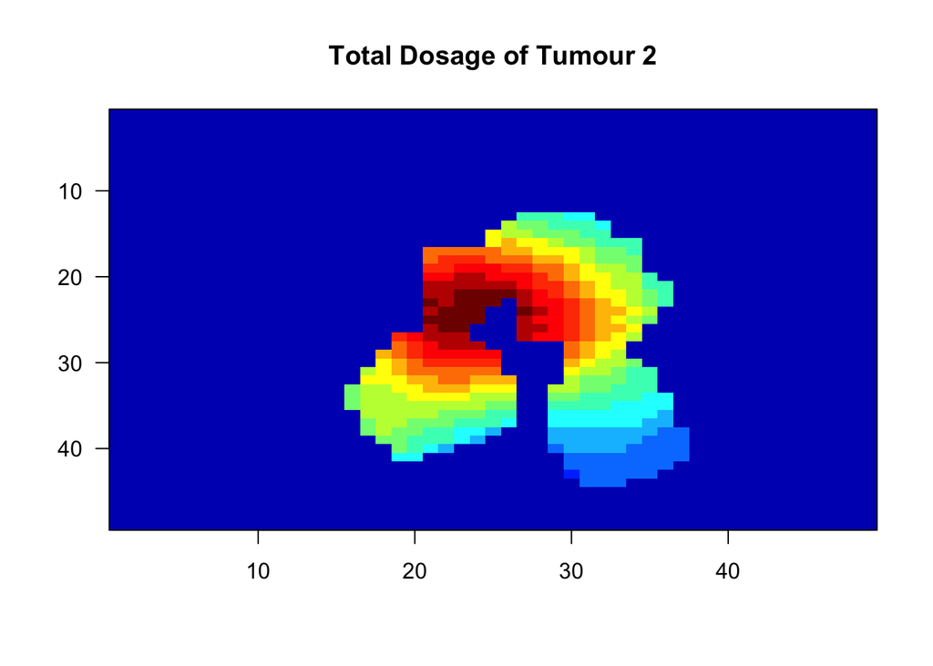

```r
#looks good

#Let's make a data frame of the total dose received at each point in the tumour
TumourDose2 <- matrix(ncol=iterationsy, nrow=iterationsx)

#And now we can populate that grid
for(i in 1:iterationsx){
  for(j in 1:iterationsy){
    TumourDose2[i,j] <- TotalDose[i,j]*Tumour2[i,j]
  }
}
#check it out
imagesc(TumourDose2, xlab="", ylab="", col=jet.colors(16), main = "Total Dosage of Tumour 2")
```

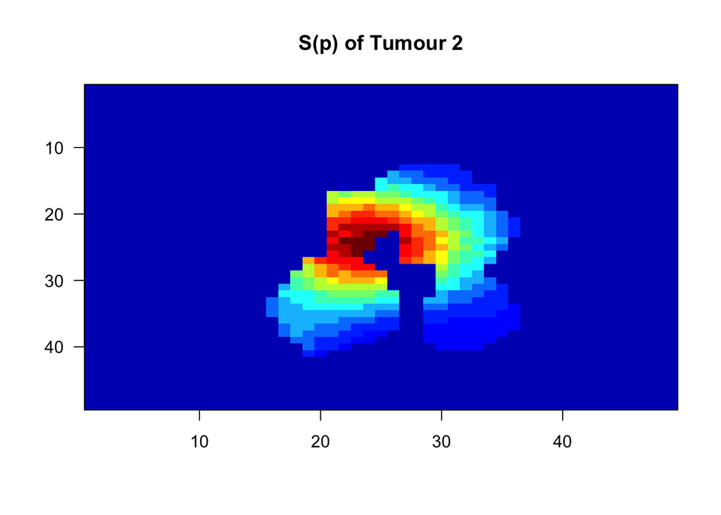

```r
#Let's make a data frame of the cell survival
CellSurvival2 <- matrix(ncol=iterationsy, nrow=iterationsx)

#And now we can populate that grid
for(i in 1:iterationsx){
  for(j in 1:iterationsy){
    CellSurvival2[i,j] <- a*(TumourDose2[i,j])+b*(TumourDose2[i,j])^2
  }
}

#visualize
imagesc(CellSurvival2, xlab="", ylab="", col=jet.colors(16), main = "S(p) of Tumour 2")
```

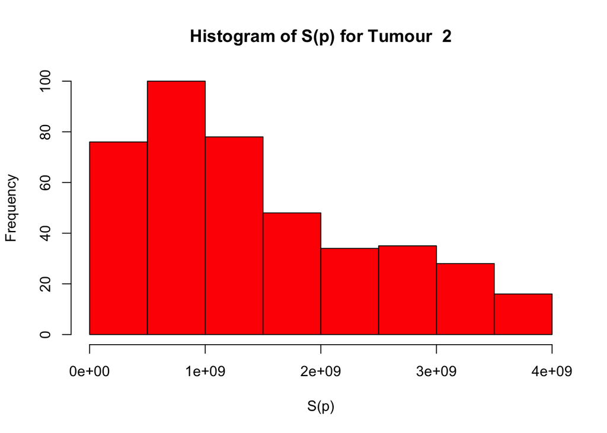

```r
#Now let's make a histogram' to visualize how zapped the tumour was
#Get rid of unecessary the zeros
HowZapped2 <- matrix(ncol=iterationsy, nrow=iterationsx)
for(i in 1:iterationsx){
  for(j in 1:iterationsy){
    if(TumourDose2[i,j]>1){
      HowZapped2[i,j] <- CellSurvival2[i,j]
    } else {
      HowZapped2[i,j] <- NA}
  }
}
HowZapped2 <- data.frame(HowZapped2)

hist(unlist(HowZapped2), main = "Histogram of S(p) for Tumour  2", xlab = "S(p)", col = "red")
```

```r
# Now let's see how many tumour cells died
deadcells2 = 0
for(i in 1:iterationsx){
  for(j in 1:iterationsy){
    if(CellSurvival1[i,j]>cutoff){
      deadcells2 <- deadcells2+1
    }
  }
}
deadcells2
```

```
## [1] 133
```

```r
#now let's calculate the percentage of the tumour that survived
#to do so we need  to quantify the size  of the original tumour
totcells2 = 0
for(i in 1:iterationsx){
  for(j in 1:iterationsy){
    if(Tumour2[i,j] == 1){
      totcells2 <- totcells2+1
    }
  }
}
totcells2
```

```
## [1] 416
```

```r
#now we can calculate the percentage of the tumour that survives
survived2 = 100*(totcells2-deadcells2)/totcells2


survived2
```

```
## [1] 68.02885
```